# Lab 04 - Multiple Linear Regression

# The data

First off we read (and manipulate a bit) the data:

```r
# read the data
fl <- "http://archive.ics.uci.edu/ml/machine-learning-databases/auto-mpg/auto-mpg.data"
autompg = read.table(fl, quote = "\"",
comment.char = "", stringsAsFactors = FALSE)
# give the dataframe headers
colnames(autompg) <- c("mpg", "cyl", "disp", "hp", "wt",
"acc", "year", "origin", "name")
# remove missing data, which is stored as "?"
autompg <-subset(autompg, autompg$hp != "?")
# remove the plymouth reliant, as it causes some issues
autompg <- subset(autompg, autompg$name != "plymouth reliant")
# give the dataset row names, based on the engine, year and name
rownames(autompg) <- paste(autompg$cyl, "cylinder",
autompg$year, autompg$name)
# remove the variable for name, as well as origin
autompg <- subset(autompg,
select = c("mpg", "cyl", "disp", "hp", "wt", "acc", "year"))
# change horsepower from character to numeric
autompg$hp <- as.numeric(autompg$hp)
```

For the moment we focus on explaining $mpg$ as a function of $wt$ and $year$.

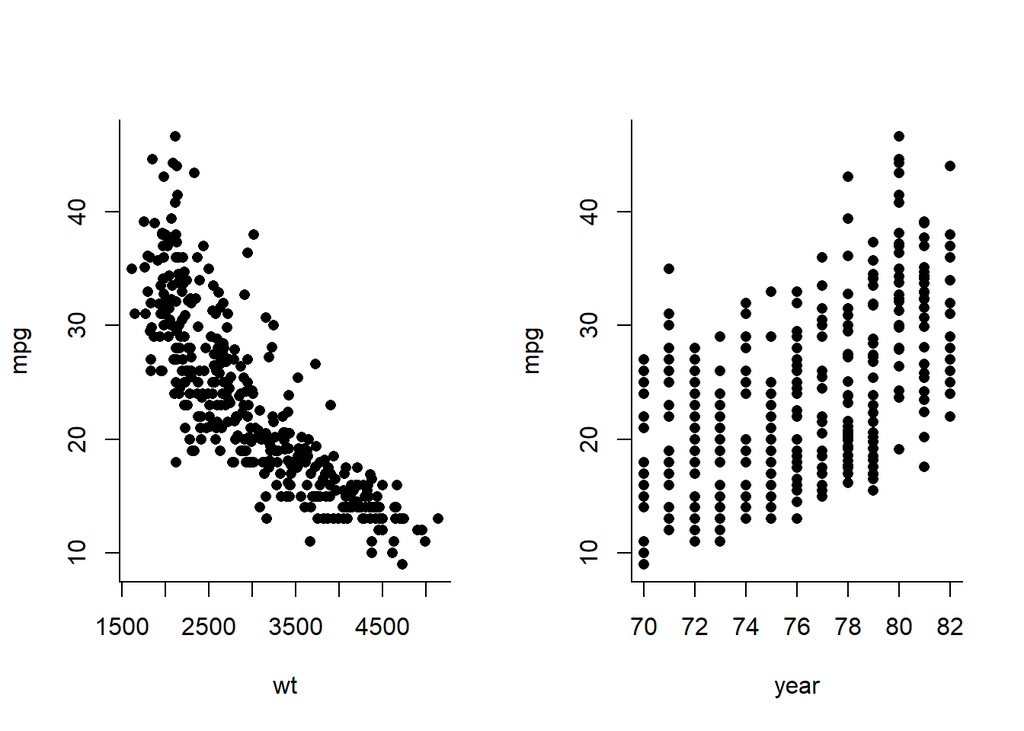

```r
par(mfrow=c(1,2), bty="l",pch=16)
plot(mpg~wt, data= autompg)
plot(mpg~year, data= autompg)
```

In the course of this lab we will make use fo an additional library (`car`) which implements a number of useful functions which expand the possible range of ways to interact with linear models in R.

We can install it using the command `install.package`, but first we check if the package is already installed. Once the package is installed we don’t need to install it again, but we can simply load it in our workspace using the command `library` (alternatively we can use the functions in the package by using the package::function syntax).

```r
if(!any(installed.packages() == "car")) install.packages("car")
library(car)
```

# Stimare un modello lineare

$$y = \beta_0 +\beta_1 wt + \beta_2 year$$

```r
fitmpg <- lm(mpg ~ wt+year, data = autompg)
summary(fitmpg)
```

```
##
## Call:
## lm(formula = mpg ~ wt + year, data = autompg)
##
## Residuals:
##    Min     1Q Median     3Q    Max
## -8.852 -2.292 -0.100  2.039 14.325
##
## Coefficients:
##               Estimate Std. Error t value Pr(>|t|)
## (Intercept) -1.464e+01  4.023e+00  -3.638 0.000312 ***
## wt          -6.635e-03  2.149e-04 -30.881  < 2e-16 ***
## year         7.614e-01  4.973e-02  15.312  < 2e-16 ***
## ---
## Signif. codes:  0 '***' 0.001 '**' 0.01 '*' 0.05 '.' 0.1 ' ' 1
##
## Residual standard error: 3.431 on 387 degrees of freedom
## Multiple R-squared:  0.8082, Adjusted R-squared:  0.8072
## F-statistic: 815.6 on 2 and 387 DF,  p-value: < 2.2e-16
```

Creiamo la matrice di disegno X:

```r
X <- cbind(rep(1, nrow(autompg)),
           autompg$wt,
           autompg$year)
head(X)
```

```
##      [,1] [,2] [,3]
## [1,]    1 3504   70
## [2,]    1 3693   70
## [3,]    1 3436   70
## [4,]    1 3433   70
## [5,]    1 3449   70
## [6,]    1 4341   70
```

```r
solve(t(X) %*% X) %*% t(X) %*% autompg$mpg
```

```
##               [,1]
## [1,] -14.637641945
## [2,]  -0.006634876
## [3,]   0.761401955
```

```r
coef(fitmpg)
```

```
##   (Intercept)            wt          year
## -14.637641945  -0.006634876   0.761401955
```

Stimiamo ora la varianza residua (cioè la varianza degli errori $\varepsilon$):

```r
sqrt(sum(residuals(fitmpg)^2)/(nrow(autompg) - 3))
```

```
## [1] 3.431367
```

```r
summary(fitmpg)$sigma
```

```
## [1] 3.431367
```

varianza-covarianza delle stime di $\beta$:

```r
(summary(fitmpg)$sigma^2) * solve(t(X) %*% X)
```

```
##               [,1]          [,2]          [,3]
## [1,] 16.1876780057 -3.862527e-04 -1.975715e-01
## [2,] -0.0003862527  4.616070e-08  3.274060e-06
## [3,] -0.1975715338  3.274060e-06  2.472734e-03
```

```r
sqrt(diag((summary(fitmpg)$sigma^2) * solve(t(X) %*% X)))
```

```
## [1] 4.0233913563 0.0002148504 0.0497265950
```

```r
summary(fitmpg)$coef[,2]
```

```
##  (Intercept)           wt         year
## 4.0233913563 0.0002148504 0.0497265950
```

```r
(summary(fitmpg)$sigma^2) * solve(t(X) %*% X)
```

```
##               [,1]          [,2]          [,3]
## [1,] 16.1876780057 -3.862527e-04 -1.975715e-01
## [2,] -0.0003862527  4.616070e-08  3.274060e-06
## [3,] -0.1975715338  3.274060e-06  2.472734e-03
```

```r
vcov(fitmpg)
```

```
##               (Intercept)            wt          year
## (Intercept) 16.1876780057 -3.862527e-04 -1.975715e-01
## wt          -0.0003862527  4.616070e-08  3.274060e-06
## year        -0.1975715338  3.274060e-06  2.472734e-03
```

```r
cov2cor(vcov(fitmpg))
```

```
##             (Intercept)         wt       year
## (Intercept)   1.0000000 -0.4468307 -0.9875142
## wt           -0.4468307  1.0000000  0.3064515
## year         -0.9875142  0.3064515  1.0000000
```

Possiamo fare inferenza sui valori singoli dei parametri:

```r
confint(fitmpg)
```

```
##                     2.5 %       97.5 %
## (Intercept) -22.548083086 -6.727200803
## wt           -0.007057296 -0.006212456
## year          0.663633861  0.859170049
```

o fare inferenza sulla distribuzione bi-variata dei parametri:

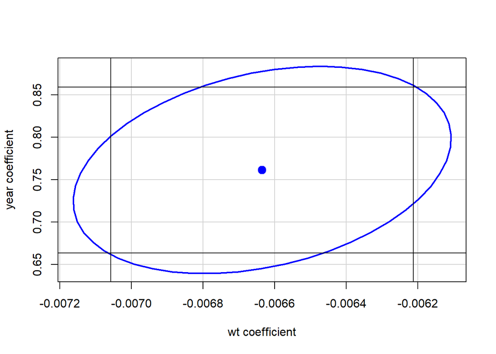

```r
library(car)
confidenceEllipse(fitmpg, which=c(2,3))
abline(v=confint(fitmpg, parm = "wt"))
abline(h=confint(fitmpg, parm = "year"))
```

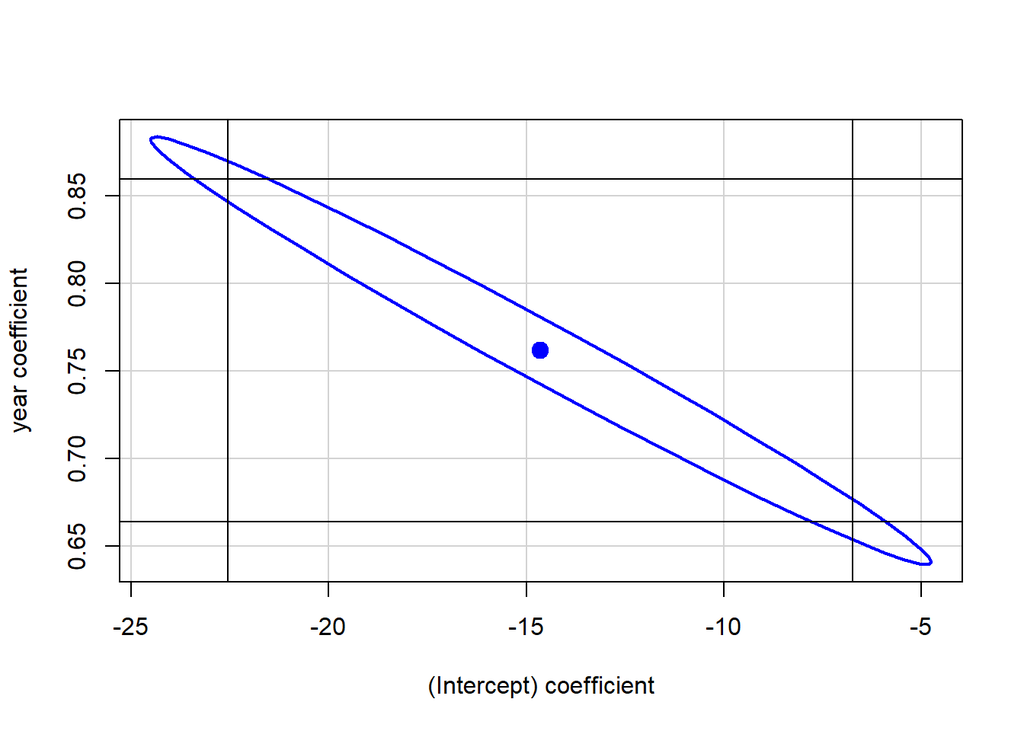

```r
confidenceEllipse(fitmpg, which=c(1,3))
abline(v=confint(fitmpg, parm = "(Intercept)"))
abline(h=confint(fitmpg, parm = "year"))
```

Matrici utili che R ci mette a disposizione

```r
head(model.matrix(fitmpg))
```

```
##                                         (Intercept)   wt year
## 8 cylinder 70 chevrolet chevelle malibu           1 3504   70
## 8 cylinder 70 buick skylark 320                   1 3693   70
## 8 cylinder 70 plymouth satellite                  1 3436   70
## 8 cylinder 70 amc rebel sst                       1 3433   70
## 8 cylinder 70 ford torino                         1 3449   70
## 8 cylinder 70 ford galaxie 500                    1 4341   70
```

```r
head(fitmpg$model)
```

```
##                                         mpg   wt year
## 8 cylinder 70 chevrolet chevelle malibu  18 3504   70
## 8 cylinder 70 buick skylark 320          15 3693   70
## 8 cylinder 70 plymouth satellite         18 3436   70
## 8 cylinder 70 amc rebel sst              16 3433   70
## 8 cylinder 70 ford torino                17 3449   70
## 8 cylinder 70 ford galaxie 500           15 4341   70
```

# Interepretare e visualizzare la stima del modello

```r
coef(fitmpg)
```

```
##   (Intercept)            wt          year
## -14.637641945  -0.006634876   0.761401955
```

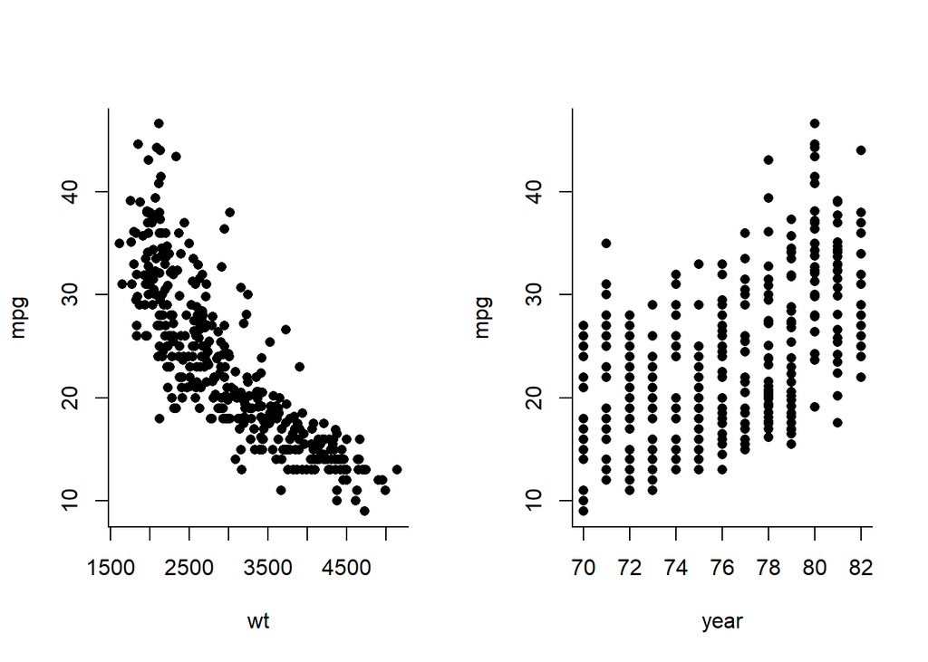

```r
par(mfrow=c(1,2), bty="l",pch=16)
plot(mpg~wt, data= autompg)
plot(mpg~year, data= autompg)
```

```r
# plot(wt~year, data= autompg)
```

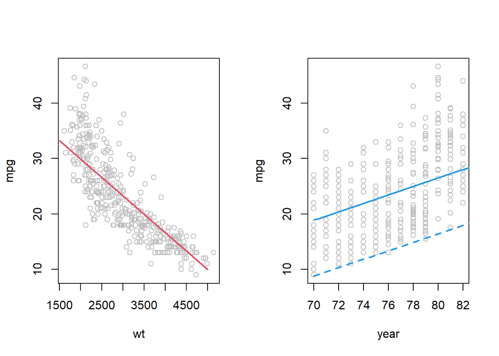

```r
par(mfrow=c(1,2))
plot(mpg~wt, data= autompg, col = "grey")
nd <- data.frame(wt = seq(1500, 5000, length.out=150),
                 year = mean(autompg$year))
lines(nd$wt,predict(fitmpg, newdata = nd), col = 2, lwd = 2)
plot(mpg~year, data= autompg, col = "grey")
nd <- data.frame(wt = mean(autompg$wt),
                 year = seq(70, 83, length.out=150))
lines(nd$year,predict(fitmpg, newdata = nd), col = 4, lwd = 2)
nd <- data.frame(wt = 4500,
                 year = seq(70, 83, length.out=150))
lines(nd$year,predict(fitmpg, newdata = nd), col = 4, lwd = 2, lty =2)
```

```r
predict(fitmpg, interval = "confidence",
        newdata = data.frame(wt = c(3500, 4000),
                                     year = c(76,76)))
```

```
##        fit      lwr      upr
## 1 20.00684 19.60000 20.41368
## 2 16.68940 16.13855 17.24025
```

```r
predict(fitmpg, interval = "prediction",
        newdata = data.frame(wt = c(3500, 4000),
                                     year = c(76,76)))
```

```
##        fit       lwr      upr
## 1 20.00684 13.248131 26.76555
## 2 16.68940  9.920498 23.45831
```